# Causes of Death in France and New York

Charles Martinez (cmm5627), Happy Situ (hys82), Jenna Webb (jnw653)

October 14, 2015

For this project we found two different data sets–each representing different causes of death in New York and France. We then used various methods to join the two data sets and then displayed interesting plots about them.

#### This is the code that we used to be able to put the data into an Oracle database:

```
require(tidyr)
require(dplyr)
require(ggplot2)

setwd("C:/Users/jenna_000/Jennas_Stuff/UT/DataVisualization/DV_RProject3/01 Data")

file_path <- "CausesOfDeath_France_2001-2008.csv"

France <- read.csv(file_path, stringsAsFactors = FALSE)

#str(France) # Uncomment this and  run just the lines to here to get column types to use for getting the list of measures.

France_measures <- c("YEAR", "Value")

dimensions <- setdiff(names(France), France_measures)
if( length(France_measures) > 1 || ! is.na(dimensions)) {
  for(d in dimensions) {
    # Get rid of " and ' in dimensions.
    France[d] <- data.frame(lapply(France[d], gsub, pattern="[\"']",replacement= ""))
    # Change & to and in dimensions.
    France[d] <- data.frame(lapply(France[d], gsub, pattern="&",replacement= " and "))
    # Change : to ; in dimensions.
    France[d] <- data.frame(lapply(France[d], gsub, pattern=":",replacement= ";"))
  }
}

library(lubridate)

# The following is an example of dealing with special cases like making state abbreviations be all upper case.
# df["State"] <- data.frame(lapply(df["State"], toupper))

# Get rid of all characters in measures except for numbers, the - sign, and period.dimensions
if( length(France_measures) > 1 || ! is.na(France_measures)) {
  for(m in France_measures) {
    France[m] <- data.frame(lapply(France[m], gsub, pattern="[^--.0-9]",replacement= ""))
  }
}

write.csv(France, paste(gsub(".csv", "", file_path), ".reformatted.csv", sep=""), row.names=FALSE, na = "")

```

[output cut: 45 more lines]

```
tableName <- gsub(" +", "_", gsub("[^A-z, 0-9, ]", "", gsub(".csv", "", file_path2)))
sql <- paste("CREATE TABLE", tableName, "(\n-- Change table_name to the table name you want.\n")
if( length(NewYork_measures) > 1 || ! is.na(NY_dimensions)) {
  for(d in NY_dimensions) {
    sql <- paste(sql, paste(d, "varchar2(4000),\n"))
  }
}
if( length(NewYork_measures) > 1 || ! is.na(NewYork_measures)) {
  for(m in NewYork_measures) {
    if(m != tail(NewYork_measures, n=1)) sql <- paste(sql, paste(m, "number(38,4),\n"))
    else sql <- paste(sql, paste(m, "number(38,4)\n"))
  }
}
sql <- paste(sql, ");")
cat(sql)
```

#### Here is a summary of our data:

```r
source("../01 Data/Death_jnw.R", echo = FALSE)
summary(df_France)
```

```
##      GEO           UNIT           SEX         AGE
##  France:1056   Number:1056   Females:528   Total:1056
##                              Males  :528
##
##
##
##
##
##                                                         CAUSE
##  Accidental poisoning by and exposure to noxious substances: 16
##  Accidents                                                 : 16
##  All causes of death (A00-Y89) excluding S00-T98           : 16
##  Assault                                                   : 16
##  Asthma and status asthmaticus                             : 16
##  Cerebrovascular diseases                                  : 16
##  (Other)                                                   :960
##       YEAR          VALUE
##  Min.   :2001   null   : 40
##  1st Qu.:2003   17     :  4
##  Median :2004   18     :  4
##  Mean   :2004   82     :  4
##  3rd Qu.:2006   555    :  3
##  Max.   :2008   68     :  3
##                 (Other):998
```

```r
summary(df_NewYork)
```

```
##                         ETHNICITY       SEX
##  ASIAN  and  PACIFIC ISLANDER:603   FEMALE:1416
##  HISPANIC                    :756   MALE  :1464
##  NON-HISPANIC BLACK          :762
##  NON-HISPANIC WHITE          :759
##
##
##
##                               CAUSEOFDEATH       YEAR
##  ACCIDENTS EXCEPT DRUG POISONING    : 120   Min.   :2007
##  BENIGN AND UNCERTAIN NEOPLASMS     : 120   1st Qu.:2008
##  CEREBROVASCULAR DISEASE            : 120   Median :2009
##  CHRONIC LIVER DISEASE AND CIRRHOSIS: 120   Mean   :2009
##  CHRONIC LOWER RESPIRATORY DISEASES : 120   3rd Qu.:2010
##  DIABETES MELLITUS                  : 120   Max.   :2011
##  (Other)                            :2160
##      COUNT           PERCENT
##  Min.   :   5.0   Min.   : 0.000
##  1st Qu.:  20.0   1st Qu.: 0.000
##  Median :  54.0   Median : 1.000
##  Mean   : 248.2   Mean   : 3.712
##  3rd Qu.: 156.0   3rd Qu.: 3.000
##  Max.   :7050.0   Max.   :49.000
##
```

#### Here is a summary and a subset after an inner join, and the code that was used to join:

```r
source("../01 Data/Death_hys.R", echo = FALSE)
```

```
innerj <- dplyr::inner_join(dfFrance, dfNYC, by="YEAR")
```

```r
summary(innerj)
```

```
##      GEO             UNIT            SEX.x          AGE
##  France:151668   Number:151668   Females:75834   Total:151668
##                                  Males  :75834
##
##
##
##
##
##                                                         CAUSE
##  Accidental poisoning by and exposure to noxious substances:  2298
##  Accidents                                                 :  2298
##  All causes of death (A00-Y89) excluding S00-T98           :  2298
##  Assault                                                   :  2298
##  Asthma and status asthmaticus                             :  2298
##  Cerebrovascular diseases                                  :  2298
##  (Other)                                                   :137880
##       YEAR          VALUE                               ETHNICITY
##  Min.   :2007   null   :  5745   ASIAN  and  PACIFIC ISLANDER:30888
##  1st Qu.:2007   17     :  1728   HISPANIC                    :39996
##  Median :2007   166    :  1149   NON-HISPANIC BLACK          :40392
##  Mean   :2007   79     :  1149   NON-HISPANIC WHITE          :40392
##  3rd Qu.:2008   82     :  1149
##  Max.   :2008   68     :  1140
##                 (Other):139608
##     SEX.y                                    CAUSEOFDEATH
##  FEMALE:75240   ACCIDENTS EXCEPT DRUG POISONING    :  6336
##  MALE  :76428   BENIGN AND UNCERTAIN NEOPLASMS     :  6336
##                 CEREBROVASCULAR DISEASE            :  6336
##                 CHRONIC LIVER DISEASE AND CIRRHOSIS:  6336
##                 CHRONIC LOWER RESPIRATORY DISEASES :  6336
##                 DIABETES MELLITUS                  :  6336
##                 (Other)                            :113652
##      COUNT           PERCENT
##  Min.   :   5.0   Min.   : 0.000
##  1st Qu.:  20.0   1st Qu.: 0.000
##  Median :  53.0   Median : 1.000
##  Mean   : 255.9   Mean   : 3.742
##  3rd Qu.: 158.0   3rd Qu.: 3.000
##  Max.   :7050.0   Max.   :49.000
##
```

```r
head(innerj)
```

```
##      GEO   UNIT SEX.x   AGE
## 1 France Number Males Total
## 2 France Number Males Total
## 3 France Number Males Total
## 4 France Number Males Total
## 5 France Number Males Total
## 6 France Number Males Total
##                                             CAUSE YEAR  VALUE
## 1 All causes of death (A00-Y89) excluding S00-T98 2007 273401
## 2 All causes of death (A00-Y89) excluding S00-T98 2007 273401
## 3 All causes of death (A00-Y89) excluding S00-T98 2007 273401
## 4 All causes of death (A00-Y89) excluding S00-T98 2007 273401
## 5 All causes of death (A00-Y89) excluding S00-T98 2007 273401
## 6 All causes of death (A00-Y89) excluding S00-T98 2007 273401
##                      ETHNICITY  SEX.y                    CAUSEOFDEATH
## 1 ASIAN  and  PACIFIC ISLANDER FEMALE ACCIDENTS EXCEPT DRUG POISONING
## 2 ASIAN  and  PACIFIC ISLANDER FEMALE              ALZHEIMERS DISEASE
## 3 ASIAN  and  PACIFIC ISLANDER FEMALE  AORTIC ANEURYSM AND DISSECTION
## 4 ASIAN  and  PACIFIC ISLANDER FEMALE              ASSAULT (HOMICIDE)
## 5 ASIAN  and  PACIFIC ISLANDER FEMALE                 ATHEROSCLEROSIS
## 6 ASIAN  and  PACIFIC ISLANDER FEMALE  BENIGN AND UNCERTAIN NEOPLASMS
##   COUNT PERCENT
## 1    32       2
## 2     7       1
## 3     9       1
## 4     6       0
## 5     5       0
## 6     6       0
```

#### A bind and its code:

```r
source("../01 Data/Death_cmm.R", echo = FALSE)
```

```
df_bind <- dplyr::left_join(df_NewYorkDeaths,df_FranceDeaths,by="YEAR")
df_bind <- dplyr::distinct(df_bind)
df_bind <- dplyr::rename(df_bind, NY_SEX = SEX.x)
df_bind <- dplyr::rename(df_bind, FRANCE_SEX = SEX.y)
```

```r
summary(df_bind)
```

```
##                         ETHNICITY        NY_SEX
##  ASIAN  and  PACIFIC ISLANDER:10419   FEMALE:25362
##  HISPANIC                    :13483   MALE  :25771
##  NON-HISPANIC BLACK          :13616
##  NON-HISPANIC WHITE          :13615
##
##
##
##                               CAUSEOFDEATH        YEAR
##  ACCIDENTS EXCEPT DRUG POISONING    : 2136   Min.   :2007
##  BENIGN AND UNCERTAIN NEOPLASMS     : 2136   1st Qu.:2007
##  CEREBROVASCULAR DISEASE            : 2136   Median :2008
##  CHRONIC LIVER DISEASE AND CIRRHOSIS: 2136   Mean   :2008
##  CHRONIC LOWER RESPIRATORY DISEASES : 2136   3rd Qu.:2008
##  DIABETES MELLITUS                  : 2136   Max.   :2011
##  (Other)                            :38317
##      COUNT           PERCENT           GEO            UNIT
##  Min.   :   5.0   Min.   : 0.000   France:50556   Number:50556
##  1st Qu.:  20.0   1st Qu.: 0.000   NA's  :  577   NA's  :  577
##  Median :  53.0   Median : 1.000
##  Mean   : 255.7   Mean   : 3.741
##  3rd Qu.: 158.0   3rd Qu.: 3.000
##  Max.   :7050.0   Max.   :49.000
##
##    FRANCE_SEX       AGE
##  Females:25278   Total:50556
##  Males  :25278   NA's :  577
##  NA's   :  577
##
##
##
##
##                                                         CAUSE
##  Accidental poisoning by and exposure to noxious substances:  766
##  Accidents                                                 :  766
##  All causes of death (A00-Y89) excluding S00-T98           :  766
##  Assault                                                   :  766
##  Asthma and status asthmaticus                             :  766
##  (Other)                                                   :46726
##  NA's                                                      :  577
##      VALUE
##  null   : 1915
##  17     :  576
##  166    :  383
##  79     :  383
##  82     :  383
##  (Other):46916
##  NA's   :  577
```

```r
head(df_bind)
```

```
##            ETHNICITY NY_SEX                              CAUSEOFDEATH YEAR
## 1 NON-HISPANIC WHITE FEMALE       CHRONIC LIVER DISEASE AND CIRRHOSIS 2011
## 2 NON-HISPANIC WHITE FEMALE        CHRONIC LOWER RESPIRATORY DISEASES 2011
## 3 NON-HISPANIC WHITE FEMALE     CONGENITAL MALFORMATIONS,DEFORMATIONS 2011
## 4 NON-HISPANIC WHITE FEMALE                         DIABETES MELLITUS 2011
## 5 NON-HISPANIC WHITE FEMALE                         DISEASES OF HEART 2011
## 6 NON-HISPANIC WHITE FEMALE ESSENTIAL HYPERTENSION AND RENAL DISEASES 2011
##   COUNT PERCENT  GEO UNIT FRANCE_SEX  AGE CAUSE VALUE
## 1    79       1 <NA> <NA>       <NA> <NA>  <NA>  <NA>
## 2   510       4 <NA> <NA>       <NA> <NA>  <NA>  <NA>
## 3    39       0 <NA> <NA>       <NA> <NA>  <NA>  <NA>
## 4   253       2 <NA> <NA>       <NA> <NA>  <NA>  <NA>
## 5  5016      37 <NA> <NA>       <NA> <NA>  <NA>  <NA>
## 6   199       1 <NA> <NA>       <NA> <NA>  <NA>  <NA>
```

#### And a full join, as well as its code:

```r
source("../01 Data/Death_jnw.R", echo = FALSE)
```

```
df_full <- dplyr::full_join(df_France, df_NewYork, by="YEAR")
```

```r
summary(df_full)
```

```
##      GEO             UNIT            SEX.x          AGE
##  France:152460   Number:152460   Females:76230   Total:152460
##  NA's  :  1731   NA's  :  1731   Males  :76230   NA's :  1731
##                                  NA's   : 1731
##
##
##
##
##                                                         CAUSE
##  Accidental poisoning by and exposure to noxious substances:  2310
##  Accidents                                                 :  2310
##  All causes of death (A00-Y89) excluding S00-T98           :  2310
##  Assault                                                   :  2310
##  Asthma and status asthmaticus                             :  2310
##  (Other)                                                   :140910
##  NA's                                                      :  1731
##       YEAR          VALUE                               ETHNICITY
##  Min.   :2001   null   :  5775   ASIAN  and  PACIFIC ISLANDER:31257
##  1st Qu.:2007   17     :  1729   HISPANIC                    :40449
##  Median :2007   82     :  1151   NON-HISPANIC BLACK          :40848
##  Mean   :2008   79     :  1150   NON-HISPANIC WHITE          :40845
##  3rd Qu.:2008   166    :  1149   NA's                        :  792
##  Max.   :2011   (Other):141506
##                 NA's   :  1731
##     SEX.y                                    CAUSEOFDEATH
##  FEMALE:76086   ACCIDENTS EXCEPT DRUG POISONING    :  6408
##  MALE  :77313   BENIGN AND UNCERTAIN NEOPLASMS     :  6408
##  NA's  :  792   CEREBROVASCULAR DISEASE            :  6408
##                 CHRONIC LIVER DISEASE AND CIRRHOSIS:  6408
##                 CHRONIC LOWER RESPIRATORY DISEASES :  6408
##                 (Other)                            :121359
##                 NA's                               :   792
##      COUNT           PERCENT
##  Min.   :   5.0   Min.   : 0.000
##  1st Qu.:  20.0   1st Qu.: 0.000
##  Median :  53.0   Median : 1.000
##  Mean   : 255.7   Mean   : 3.741
##  3rd Qu.: 158.0   3rd Qu.: 3.000
##  Max.   :7050.0   Max.   :49.000
##  NA's   :792      NA's   :792
```

```r
head(df_full)
```

```
##      GEO   UNIT SEX.x   AGE
## 1 France Number Males Total
## 2 France Number Males Total
## 3 France Number Males Total
## 4 France Number Males Total
## 5 France Number Males Total
## 6 France Number Males Total
##                                                                      CAUSE
## 1                                            Malignant neoplasms (C00-C97)
## 2                          Malignant neoplasm of lip, oral cavity, pharynx
## 3                                         Malignant neoplasm of oesophagus
## 4                                            Malignant neoplasm of stomach
## 5                                              Malignant neoplasm of colon
## 6 Malignant neoplasm of rectosigmoid junction, rectum, anus and anal canal
##   YEAR VALUE ETHNICITY SEX.y CAUSEOFDEATH COUNT PERCENT
## 1 2003 89397      <NA>  <NA>         <NA>    NA      NA
## 2 2003  3635      <NA>  <NA>         <NA>    NA      NA
## 3 2003  3401      <NA>  <NA>         <NA>    NA      NA
## 4 2003  3174      <NA>  <NA>         <NA>    NA      NA
## 5 2003  6314      <NA>  <NA>         <NA>    NA      NA
## 6 2003  2325      <NA>  <NA>         <NA>    NA      NA
```

### Plots 1 & 2:

```r
source("../02 Data Wrangling/InnerJoin.R", echo = TRUE)
```

```
##
## > dfFrance <- data.frame(fromJSON(getURL(URLencode("129.152.144.84:5001/rest/native/?query=\"select * from DeathsFrance\""),
## +     httpheader = c(DB  .... [TRUNCATED]
##
## > dfNYC <- data.frame(fromJSON(getURL(URLencode("129.152.144.84:5001/rest/native/?query=\"select * from DeathsNYC\""),
## +     httpheader = c(DB = "jdb ..." ... [TRUNCATED]
##
## > innerj <- dplyr::inner_join(dfFrance, dfNYC, by = "YEAR")
##
## > innerj %>% select(YEAR, ETHNICITY, SEX.x, SEX.y, CAUSE,
## +     CAUSEOFDEATH, COUNT, VALUE) %>% filter(CAUSEOFDEATH == "ASSAULT (HOMICIDE)",
## +     C .... [TRUNCATED]
```

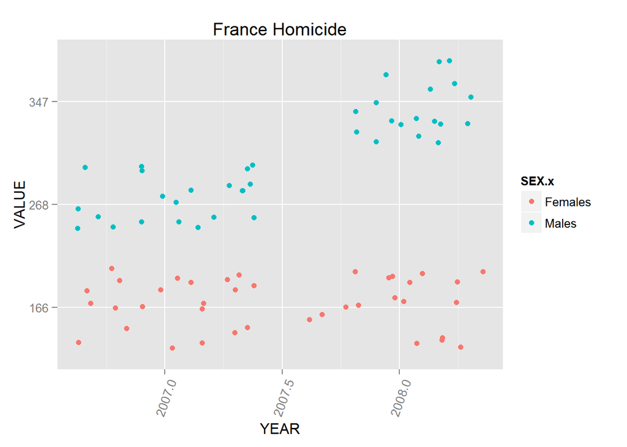

```
##
## > innerj %>% select(YEAR, ETHNICITY, SEX.x, SEX.y, CAUSE,
## +     CAUSEOFDEATH, COUNT, VALUE) %>% filter(CAUSEOFDEATH == "ASSAULT (HOMICIDE)",
## +     C .... [TRUNCATED]
```

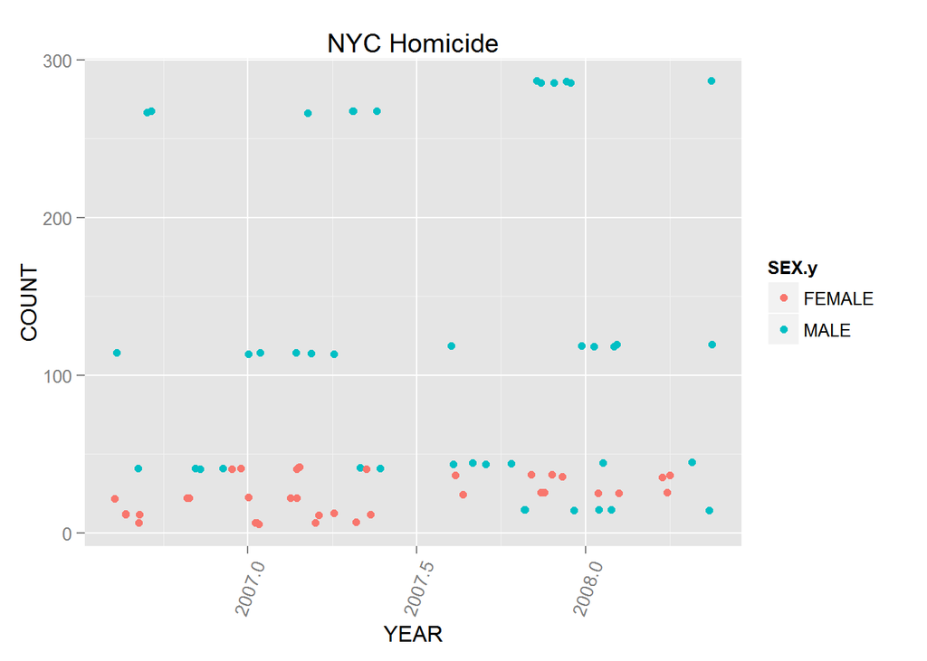

Plot 1 shows that the number of male deaths due to homicide in France have been strictly higher in the years 2007 and 2008. Plot 2 does not have this stict relation, and from 2007 to 2008 New York City’s count for homicides is pretty much the same. In plot 1 the number of males death in France increased from 2007 to 2008.